# HRmax Calculator

John Letteboer  
03-03-2019

### Overview

This is an RStudio shiny application developed as a part of final project in the Developing Data Products course in the Coursera Data Science Specialization track.

The application calculates your maximum heart rate and the target heart rate zones for the chosen age.

The application includes:

- Its build with shinydashboardPlus library
- Tab menus
- Slider inputs for age, minimum and maximum intensiy
- A short documentation

This app is hosted at https://jletteboer.shinyapps.io/calculate_maximum_heartrate/

The code can be found at https://github.com/jletteboer/Coursera/tree/master/09%20Developing%20Data%20Products

### Application widgets Used

This application uses the listed widgets below.

- widgetUserBox, This box is where the author is mentioned
- gradientBox, These boxes contains the sliderInputs for age, minimum and maximum intensity
- sliderInput, Used for 3 inputs, for age (years), minimum (%) and maximum (%) intensity
- valueBoxOutput, Output bix for showing the results

[figure not shown]

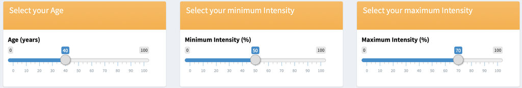

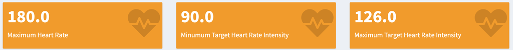

### Operations in the App

What is happening inside the app, here is a simple example.

### Calculation of maximum heart rate

```r
input_age <- 45
hrmax <- 220 - input_age
hrmax
```

```
[1] 175
```

### Calculation of Target HR Zone

```r
input_age <- 45
input_minimum_intensity <- 50
input_maximum_intensity <- 70
minimum_intensity <- 220 - input_age * input_minimum_intensity/100
maximum_intensity <- 220 - input_age * input_maximum_intensity/100
paste0("Target HR Zone of ", input_minimum_intensity, "-",
       input_maximum_intensity, "% is between ", minimum_intensity, " and ",
       maximum_intensity, " for ", input_age, " years old.")
```

[output not shown]

### Documentation in the App

There is adocumentation area in the app. It can be accessed via the menu.

### Usage

Fill in your age, minimum and maximum intensity with the sliders and see what your maximum and target heart rates are.